# Topic 1 Exercises

## 2.4.1

1. Flexible will be better off due to large sample size.
2. Flexible will be worse off due to small sample size.
3. Flexible will be better off because it has higher degrees of freedom as it is non-linear.
4. Flexible will be worse off because it will try to fit to the noise caused by high variance.

## 2.4.2

1. This is a regression problem because we are interested in finding factors that affect CEO salary, which is a number not a category. We are interested in inference because we will use this model to see how these factors affect current CEO salaries, instead of making a prediction about something in the future. n = 500. p = 3.
2. This is a classification problem because we are interested in finding out whether our new product will be a success or failure, which are two categoires. We are interested in prediction because we will use this model to predict if this product will succeed in the future. n = 20. p = 13.
3. This is a regression problem because we are interested in finding the % change in US dollars, which is a numerical value. We are interested in prediction because we want to use this model to predict how future US dollars are impacted by other global markets. n = 52. p = 3.

## 2.4.3

As flexibility increases, the training MSE falls because the f curve fits the data more closely as flexibility increases.

Similarly, test MSE falls as flexibility increases. However, it is u-shaped and starts rising when flexibility gets too large. This is because when flexibility gets too high, training data is large because we begin overfitting the data.

The squared bias decreases as flexibility increases. This is because it is unlikely any real life mondel has a simple linear relationship. So when there is low flexiility (linear), the estimates of f will include quite a lot of bias.

Variance increases as flexibility increases. When flexibility is high, the model usually fits the observations very closely. So changing any point will cause variance to increase.

The irreducible error is a straight line with no slope because it is a constant. the test MSE curve is always above the irreducible error line.

## 2.4.6

The parametric model assumes a shape for f which means a set of parameteres needs to be added to make f represent the data better. The non-parametric model doesn’t assume a shape for f and instead directly uses the data to create a model that corresponds to individual data points as close as possible. The advantages of a parametric approach are: it reduces the problem of estimating f to one of estimating a set of parameters. This makes it simpler becuase it’s easier to estimate parameters rather than estimate a model f. The disadvantages of a parametric approach are: the model we choose will usually not match the true unknown form of f which can lead to our estimate being poor. It can also overfit the observations if more flexible models are used.

## 2.4.7

```r
distance <- matrix(c("1","0","3","0","red","3","2","2","0","0","red","2","3","0","1","3","red","3.16","4","0","1","2","green","2.23","5","-1","0","1","green","1.41","6","1","1","1","red","1.73"),ncol=6,byrow=TRUE)
colnames(distance) <- c("Obs","X1","X2","X3","Y","Distance")
distance <- as.table(distance)
distance
```

```
##   Obs X1 X2 X3 Y     Distance
## A 1   0  3  0  red   3
## B 2   2  0  0  red   2
## C 3   0  1  3  red   3.16
## D 4   0  1  2  green 2.23
## E 5   -1 0  1  green 1.41
## F 6   1  1  1  red   1.73
```

2. When K=1, X5 is an element of N0. P(Y=Red|X=X0)=I(Y5=Red) = 0 P(Y=Green|X=X0)=I(Y5=Green)= 1 Therefore our prediction is Green.
3. When K=3, X2, X5, and X6 are elements of N0. P(Y=Red|X=X0)=(1/3)(1+0+1) = (2/3) P(Y=Green|X=X0)=(1/3)(0+1+0) = (1/3) Therefore our prediction is Red (because 2/3 is larger than 1/3)
4. We would expect the ideal K value to be smaller. This is because as K becomes larger, the boundary becomes more linear.

## 2.4.8

```r
library(ISLR)
download.file("http://www-bcf.usc.edu/~gareth/ISL/College.csv", destfile="College.csv")
auto_file_name = "/home/local/MAC/mroffler/Math-253 Assignments/College.csv"
college = read.csv("/home/local/MAC/mroffler/Math-253 Assignments/College.csv")
```

```r
rownames (college )=college [,1]
head(college)
```

```
##                                                         X Private Apps
## Abilene Christian University Abilene Christian University     Yes 1660
## Adelphi University                     Adelphi University     Yes 2186
## Adrian College                             Adrian College     Yes 1428
## Agnes Scott College                   Agnes Scott College     Yes  417
## Alaska Pacific University       Alaska Pacific University     Yes  193
## Albertson College                       Albertson College     Yes  587
##                              Accept Enroll Top10perc Top25perc F.Undergrad
## Abilene Christian University   1232    721        23        52        2885
## Adelphi University             1924    512        16        29        2683
## Adrian College                 1097    336        22        50        1036
## Agnes Scott College             349    137        60        89         510
## Alaska Pacific University       146     55        16        44         249
## Albertson College               479    158        38        62         678
##                              P.Undergrad Outstate Room.Board Books
## Abilene Christian University         537     7440       3300   450
## Adelphi University                  1227    12280       6450   750
## Adrian College                        99    11250       3750   400
## Agnes Scott College                   63    12960       5450   450
## Alaska Pacific University            869     7560       4120   800
## Albertson College                     41    13500       3335   500
##                              Personal PhD Terminal S.F.Ratio perc.alumni
## Abilene Christian University     2200  70       78      18.1          12
## Adelphi University               1500  29       30      12.2          16
## Adrian College                   1165  53       66      12.9          30
## Agnes Scott College               875  92       97       7.7          37
## Alaska Pacific University        1500  76       72      11.9           2
## Albertson College                 675  67       73       9.4          11
##                              Expend Grad.Rate
## Abilene Christian University   7041        60
## Adelphi University            10527        56
## Adrian College                 8735        54
## Agnes Scott College           19016        59
## Alaska Pacific University     10922        15
## Albertson College              9727        55
```

```r
summary(college)
```

```
##                             X       Private        Apps
##  Abilene Christian University:  1   No :212   Min.   :   81
##  Adelphi University          :  1   Yes:565   1st Qu.:  776
##  Adrian College              :  1             Median : 1558
##  Agnes Scott College         :  1             Mean   : 3002
##  Alaska Pacific University   :  1             3rd Qu.: 3624
##  Albertson College           :  1             Max.   :48094
##  (Other)                     :771
##      Accept          Enroll       Top10perc       Top25perc
##  Min.   :   72   Min.   :  35   Min.   : 1.00   Min.   :  9.0
##  1st Qu.:  604   1st Qu.: 242   1st Qu.:15.00   1st Qu.: 41.0
##  Median : 1110   Median : 434   Median :23.00   Median : 54.0
##  Mean   : 2019   Mean   : 780   Mean   :27.56   Mean   : 55.8
##  3rd Qu.: 2424   3rd Qu.: 902   3rd Qu.:35.00   3rd Qu.: 69.0
##  Max.   :26330   Max.   :6392   Max.   :96.00   Max.   :100.0
##
##   F.Undergrad     P.Undergrad         Outstate       Room.Board
##  Min.   :  139   Min.   :    1.0   Min.   : 2340   Min.   :1780
##  1st Qu.:  992   1st Qu.:   95.0   1st Qu.: 7320   1st Qu.:3597
##  Median : 1707   Median :  353.0   Median : 9990   Median :4200
##  Mean   : 3700   Mean   :  855.3   Mean   :10441   Mean   :4358
##  3rd Qu.: 4005   3rd Qu.:  967.0   3rd Qu.:12925   3rd Qu.:5050
##  Max.   :31643   Max.   :21836.0   Max.   :21700   Max.   :8124
##
##      Books           Personal         PhD            Terminal
##  Min.   :  96.0   Min.   : 250   Min.   :  8.00   Min.   : 24.0
##  1st Qu.: 470.0   1st Qu.: 850   1st Qu.: 62.00   1st Qu.: 71.0
##  Median : 500.0   Median :1200   Median : 75.00   Median : 82.0
##  Mean   : 549.4   Mean   :1341   Mean   : 72.66   Mean   : 79.7
##  3rd Qu.: 600.0   3rd Qu.:1700   3rd Qu.: 85.00   3rd Qu.: 92.0
##  Max.   :2340.0   Max.   :6800   Max.   :103.00   Max.   :100.0
##
##    S.F.Ratio      perc.alumni        Expend        Grad.Rate
##  Min.   : 2.50   Min.   : 0.00   Min.   : 3186   Min.   : 10.00
##  1st Qu.:11.50   1st Qu.:13.00   1st Qu.: 6751   1st Qu.: 53.00
##  Median :13.60   Median :21.00   Median : 8377   Median : 65.00
##  Mean   :14.09   Mean   :22.74   Mean   : 9660   Mean   : 65.46
##  3rd Qu.:16.50   3rd Qu.:31.00   3rd Qu.:10830   3rd Qu.: 78.00
##  Max.   :39.80   Max.   :64.00   Max.   :56233   Max.   :118.00
##
```

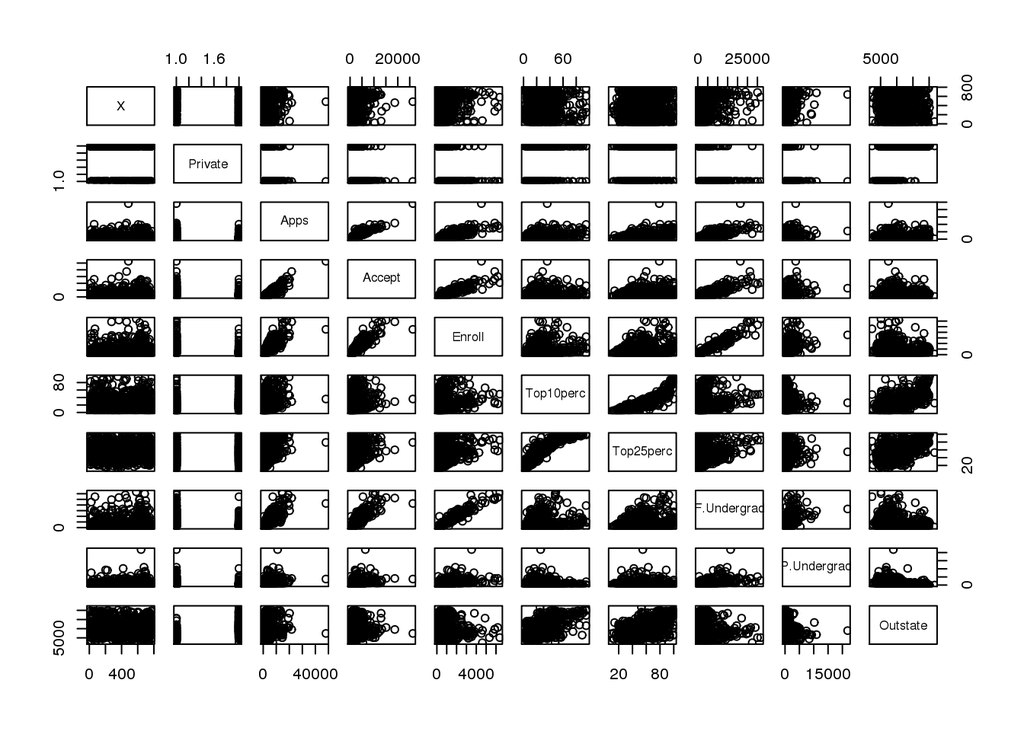

```r
pairs(college[, 1:10])
```

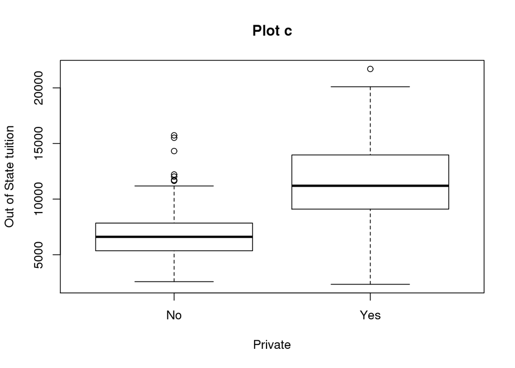

```r
plot(college$Private, college$Outstate, xlab = "Private", ylab ="Out of State tuition", main = "Plot c")
```

```r
Elite <- rep("No", nrow(college))
Elite[college$Top10perc > 50] <- "Yes"
Elite <- as.factor(Elite)
college$Elite <- Elite
summary(college$Elite)
```

```
##  No Yes
## 699  78
```

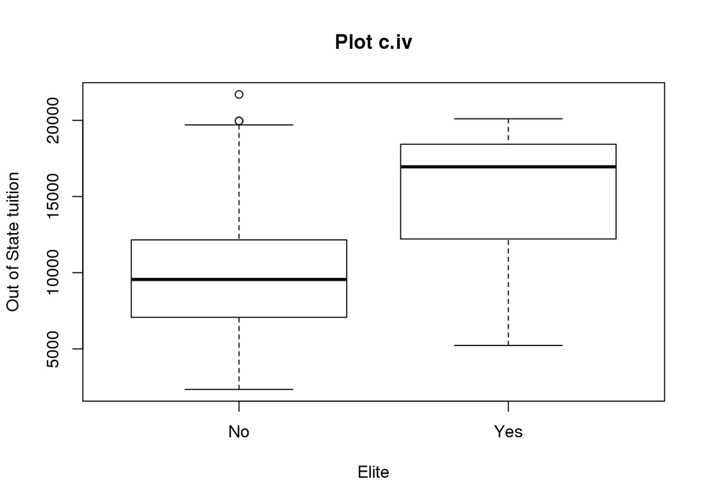

```r
plot(college$Elite, college$Outstate, xlab = "Elite", ylab ="Out of State tuition", main = "Plot c.iv")
```

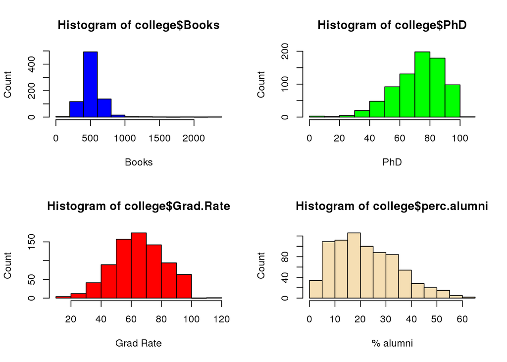

```r
par(mfrow = c(2,2))
hist(college$Books, col = "blue", xlab = "Books", ylab = "Count")
hist(college$PhD, col = "green", xlab = "PhD", ylab = "Count")
hist(college$Grad.Rate, col = "red", xlab = "Grad Rate", ylab = "Count")
hist(college$perc.alumni, col = "wheat", xlab = "% alumni", ylab = "Count")
```

```r
variable.names(College)
```

```
##  [1] "Private"     "Apps"        "Accept"      "Enroll"      "Top10perc"
##  [6] "Top25perc"   "F.Undergrad" "P.Undergrad" "Outstate"    "Room.Board"
## [11] "Books"       "Personal"    "PhD"         "Terminal"    "S.F.Ratio"
## [16] "perc.alumni" "Expend"      "Grad.Rate"
```

```r
summary(college$Apps)
```

```
##    Min. 1st Qu.  Median    Mean 3rd Qu.    Max.
##      81     776    1558    3002    3624   48090
```

## 2.4.9

```r
auto <- read.csv("Auto.csv", na.strings = "?")
auto <- na.omit(auto)
str(auto)
```

```
## 'data.frame':    392 obs. of  9 variables:
##  $ mpg         : num  18 15 18 16 17 15 14 14 14 15 ...
##  $ cylinders   : int  8 8 8 8 8 8 8 8 8 8 ...
##  $ displacement: num  307 350 318 304 302 429 454 440 455 390 ...
##  $ horsepower  : int  130 165 150 150 140 198 220 215 225 190 ...
##  $ weight      : int  3504 3693 3436 3433 3449 4341 4354 4312 4425 3850 ...
##  $ acceleration: num  12 11.5 11 12 10.5 10 9 8.5 10 8.5 ...
##  $ year        : int  70 70 70 70 70 70 70 70 70 70 ...
##  $ origin      : int  1 1 1 1 1 1 1 1 1 1 ...
##  $ name        : Factor w/ 304 levels "amc ambassador brougham",..: 49 36 231 14 161 141 54 223 241 2 ...
##  - attr(*, "na.action")=Class 'omit'  Named int [1:5] 33 127 331 337 355
##   .. ..- attr(*, "names")= chr [1:5] "33" "127" "331" "337" ...
```

1. Qualitative: name Quantitative: mpg, cylinders, displacement, horsepower, weight, acceleration, year, origin

```r
mpgRange <- range(auto$mpg)
cylindersRange <- range(auto$cylinders)
displacementRange <- range(auto$displacement)
horsepowerRange <- range(auto$horsepower)
weightRange <- range(auto$weight)
accelerationRange <- range(auto$acceleration)
yearRange <- range(auto$year)
originRange <- range(auto$origin)
```

```r
mpgMean <- mean(auto$mpg)
mpgSD <- sd(auto$mpg)
cylindersMean <- mean(auto$cylinders)
cylindersSD <- sd(auto$cylinders)
displacementMean <- mean(auto$displacement)
displacementSD <- sd(auto$displacement)
horsepowerMean <- mean(auto$horsepower)
horsepowerSD <- sd(auto$horsepower)
weightMean <- mean(auto$weight)
weightSD <- sd(auto$weight)
accelerationMean <- mean(auto$acceleration)
accelerationSD <- sd(auto$acceleration)
yearMean <- mean(auto$year)
yearSD <- sd(auto$year)
originMean <- mean(auto$origin)
originSD <- sd(auto$origin)
```

```r
subset <- auto[-c(10:85), -c(4,9)]
sapply(subset, range)
```

```
##       mpg cylinders displacement weight acceleration year origin
## [1,] 11.0         3           68   1649          8.5   70      1
## [2,] 46.6         8          455   4997         24.8   82      3
```

```r
sapply(subset, mean)
```

```
##          mpg    cylinders displacement       weight acceleration
##    24.404430     5.373418   187.240506  2935.971519    15.726899
##         year       origin
##    77.145570     1.601266
```

```r
sapply(subset, sd)
```

```
##          mpg    cylinders displacement       weight acceleration
##     7.867283     1.654179    99.678367   811.300208     2.693721
##         year       origin
##     3.106217     0.819910
```

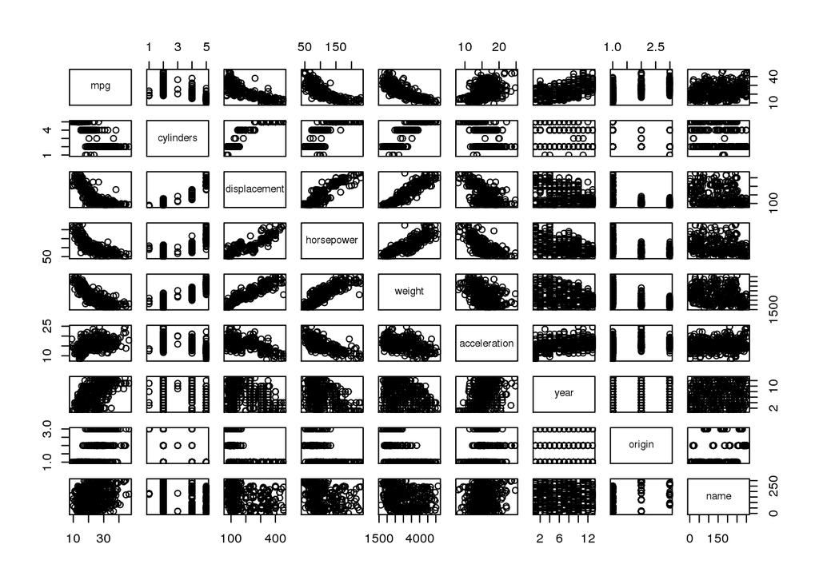

```r
auto$cylinders <- as.factor(auto$cylinders)
auto$year <- as.factor(auto$year)
auto$origin <- as.factor(auto$origin)
pairs(auto)
```

We can see some general trends here. The year of the car seems to be positively correlated with a lot of factors, such as mpg. mpg is also negative correlated with weight and horsepower.

```r
auto$horsepower <- as.numeric(auto$horsepower)
cor(auto$weight, auto$horsepower)
```

```
## [1] 0.8645377
```

```r
cor(auto$weight, auto$displacement)
```

```
## [1] 0.9329944
```

```r
cor(auto$displacement, auto$horsepower)
```

```
## [1] 0.897257
```

which are all high correlation values.